# BIOS 611 HW3 Exploratory Analysis, tibbles, and data import (Chapters 7, 10, and 11.2)

Emily Damone 730260511

09/13/2018

This homework is due `Monday September 17th by 6pm`.  
Both `.Rmd` and `.html` files should be submitted.  
(This set of exercise is mostly taken from R for Data Science by Garrett Grolemund and Hadley Wickham.)

# Exercise 1

1. Explore the distribution of `price`. Do you discover anything unusual or surprising? (Hint: Carefully think about the `binwidth` and make sure you try a wide range of values.)

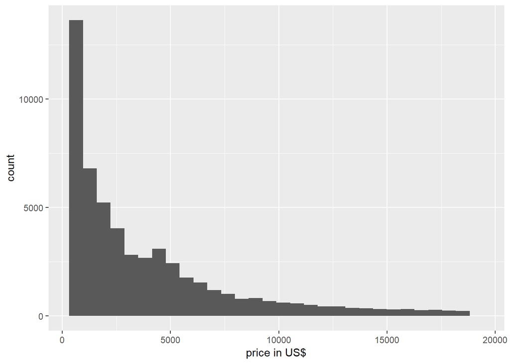

   ```r
   ggplot2::diamonds %>%
     ggplot()+
     geom_histogram(aes(ggplot2::diamonds$price))+
     xlab("price in US$")
   ```

The distribution looks approximately exponential. This doesn’t surprise me as there are many diamonds that flood the market at lower prices and only few which are worth more.

2. Compare and contrast `coord_cartesian()` vs `xlim()` or `ylim()` when zooming in on a histogram.

`coord_cartesian()` will create the whole plot and then zoom in on the given portion of the plot specified, while `xlim()` and `ylim()` will only create the specified portion of the plot and not the rest.

# Exercise 2

1. There are several ways of getting complete data (i.e. ignoring the incomplete cases). Using each of the following functions, try to get complete data.

```r
    # Use this dataset
    data.a = data.frame(no = 1:5, abc = letters[1:5], ABC = LETTERS[11:15], rand = rnorm(5))
    data.a[3,3] <- data.a[2,1] <- NA
    # A. na.omit
    data.a.complete.a <- na.omit(data.a)
    # B. complete.cases
    data.a.complete.b <- data.a[complete.cases(data.a),]

    data.a
```

```
##   no abc  ABC       rand
## 1  1   a    K -0.2235099
## 2 NA   b    L -0.6275673
## 3  3   c <NA> -1.6517156
## 4  4   d    N -0.1811682
## 5  5   e    O -0.8806154
```

```r
    data.a.complete.a
```

```
##   no abc ABC       rand
## 1  1   a   K -0.2235099
## 4  4   d   N -0.1811682
## 5  5   e   O -0.8806154
```

```r
    data.a.complete.b
```

```
##   no abc ABC       rand
## 1  1   a   K -0.2235099
## 4  4   d   N -0.1811682
## 5  5   e   O -0.8806154
```

2. What does `na.rm = TRUE` do in `mean()` and `sum()`?

   `na.rm=TRUE` removes any missing values from the vector before either mean and sum are calculated.
3. We want to see if there is a pattern of delay according to the scheduled departure time. Criticize the following graph. (If you cannot notice the problem, go back to the example in the note and see why they used `mutate` function. Note only a small sample was used for convenience.)

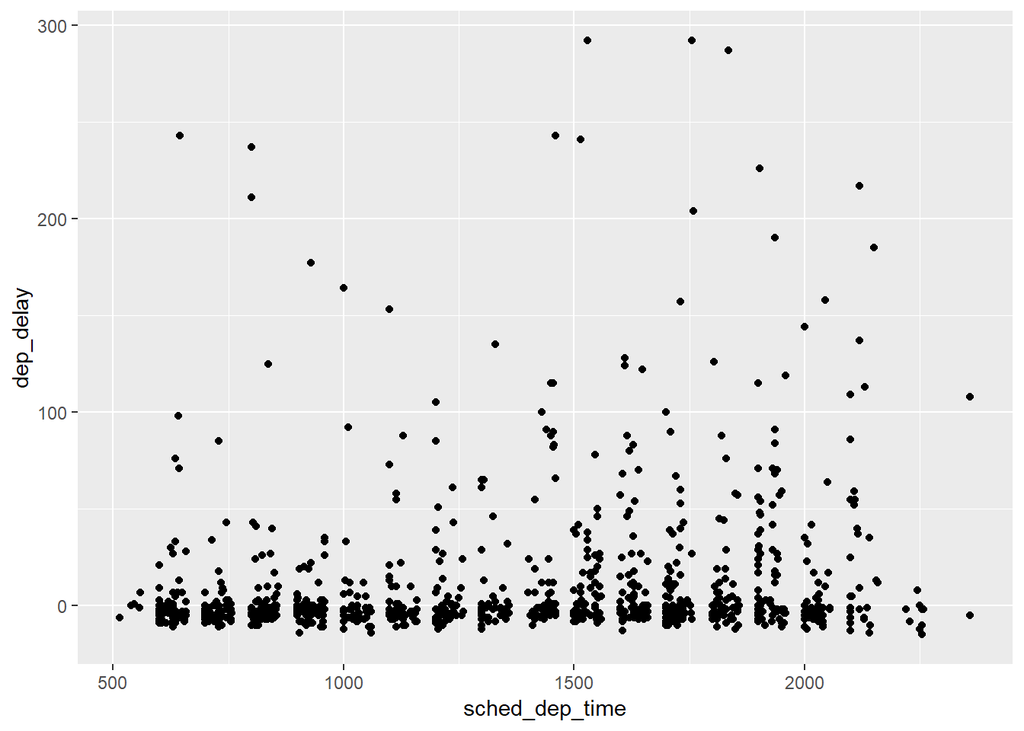

   ```r
   set.seed(1)
   newdata = sample_n(nycflights13::flights, 1000)
   newdata %>% ggplot(aes(sched_dep_time, dep_delay)) + geom_point()
   ```

They didn’t take out the missing values, nor were the scheduled departure times changed to be minutes after midnight (so there are never any values after 59 for each hour)